# Guide en classe - Atelier 03

## Question centrale

> Quelle méthode fournit une prévision assez précise et assez stable pour planifier la demande des treize prochaines semaines?

## Préparation

```r
library(tidyverse)
library(slider)
library(forecast)

data_path <- if (file.exists("data/demande_hebdomadaire_quebec.csv")) {
  "data/demande_hebdomadaire_quebec.csv"
} else {
  "modules/atelier-03-series-chronologiques/data/demande_hebdomadaire_quebec.csv"
}

demande <- read_csv(data_path, show_col_types = FALSE) |>
  mutate(semaine = as.Date(semaine)) |>
  arrange(semaine)
```

## Étape 1 - Auditer le temps

```r
demande |>
  summarise(
    debut = min(semaine),
    fin = max(semaine),
    semaines = n(),
    dates_uniques = n_distinct(semaine),
    valeurs_manquantes = sum(is.na(demande))
  )
```

```
# A tibble: 1 × 5
  debut      fin        semaines dates_uniques valeurs_manquantes
  <date>     <date>        <int>         <int>              <int>
1 2024-01-01 2025-12-22      104           104                  0
```

**AstuceTrace 1**

Écrivez l’unité d’observation, la fréquence, la période, la cible et l’horizon.

## Étape 2 - Explorer

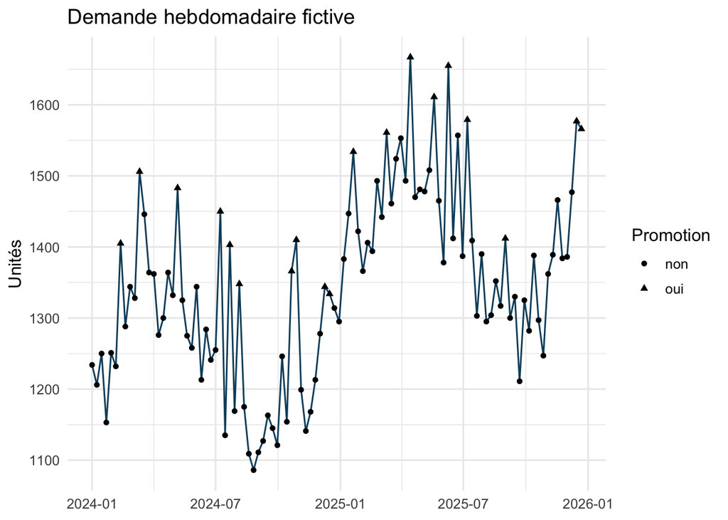

```r
ggplot(demande, aes(semaine, demande)) +
  geom_line(colour = "#0B4F6C") +
  geom_point(aes(shape = promotion), size = 1.5) +
  labs(title = "Demande hebdomadaire fictive", x = NULL, y = "Unités", shape = "Promotion") +
  theme_minimal(base_size = 12)
```

**AstuceTrace 2**

Décrivez un motif stable, un motif incertain et une limite du graphique.

## Étape 3 - Geler la période de validation

Les treize dernières semaines reprennent le cas de transfert du module 06. Elles servent à comparer les méthodes annoncées ci-dessous. Les paramètres sont estimés sur les semaines précédentes; les scores obtenus ne constituent pas un test final indépendant du choix de méthode.

```r
horizon <- 13
entrainement <- demande |> slice_head(n = nrow(demande) - horizon)
test <- demande |> slice_tail(n = horizon)
```

Notez explicitement la dernière date d’entraînement et la première date de validation.

## Étape 4 - Construire les références

La capsule 2 du module 07 explique Holt : un niveau, une pente et, ici, un amortissement de la pente. Cette méthode complète les références naïves et le lissage simple; elle n’intègre pas explicitement la saisonnalité.

```r
serie <- ts(entrainement$demande, frequency = 52)
prevision_holt <- holt(serie, h = horizon, damped = TRUE, level = c(80, 95))

previsions <- test |>
  transmute(
    semaine,
    observe = demande,
    naive = tail(entrainement$demande, 1),
    saison_naive = as.numeric(snaive(serie, h = horizon)$mean),
    moyenne_4 = mean(tail(entrainement$demande, 4)),
    SES = as.numeric(ses(serie, h = horizon)$mean),
    Holt = as.numeric(prevision_holt$mean)
  )
```

## Étape 5 - Comparer

```r
evaluation <- previsions |>
  pivot_longer(naive:Holt, names_to = "methode", values_to = "prevision") |>
  mutate(erreur = observe - prevision)

tableau_mesures <- evaluation |>
  group_by(methode) |>
  summarise(
    MAE = mean(abs(erreur)),
    RMSE = sqrt(mean(erreur^2)),
    biais = mean(erreur),
    erreur_max = max(abs(erreur)),
    .groups = "drop"
  ) |>
  arrange(MAE)

tableau_mesures
```

```
# A tibble: 5 × 5
  methode        MAE  RMSE biais erreur_max
  <chr>        <dbl> <dbl> <dbl>      <dbl>
1 moyenne_4     100.  128.  82.6       264.
2 SES           114.  144. 106.        287.
3 Holt          152.  189. 152.        354.
4 saison_naive  179.  194. 143.        298
5 naive         185.  209. 185.        366
```

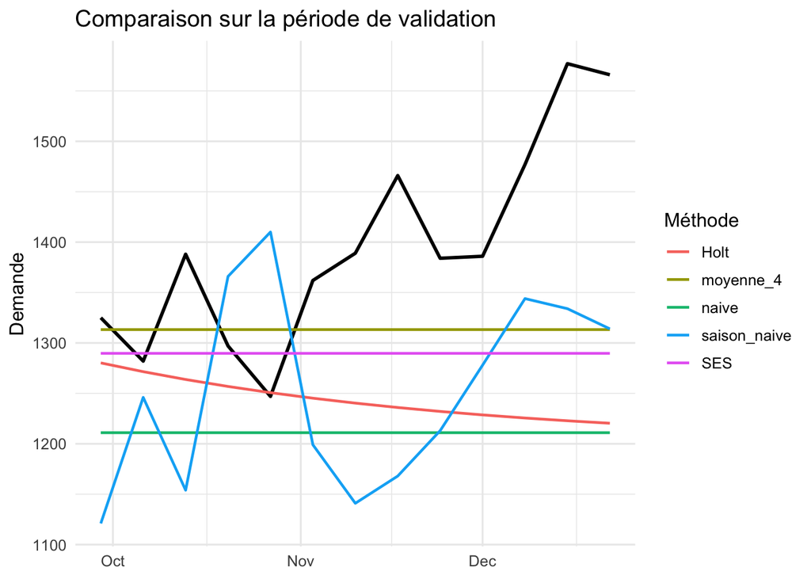

```r
evaluation |>
  ggplot(aes(semaine)) +
  geom_line(aes(y = observe), colour = "black", linewidth = 1) +
  geom_line(aes(y = prevision, colour = methode), linewidth = 0.8) +
  labs(title = "Comparaison sur la période de validation", x = NULL, y = "Demande", colour = "Méthode") +
  theme_minimal(base_size = 12)
```

**AstuceTrace 3**

Choisissez une méthode et citez au moins deux mesures. Expliquez une raison de ne pas suivre aveuglément le classement.

## Étape 5b - Rendre l’incertitude visible

```r
tibble(
  semaine = test$semaine,
  prevision = as.numeric(prevision_holt$mean),
  borne_80_inf = prevision_holt$lower[, "80%"],
  borne_80_sup = prevision_holt$upper[, "80%"],
  borne_95_inf = prevision_holt$lower[, "95%"],
  borne_95_sup = prevision_holt$upper[, "95%"]
) |>
  mutate(across(where(is.numeric), ~ round(.x))) |>
  knitr::kable()
```

| semaine | prevision | borne_80_inf | borne_80_sup | borne_95_inf | borne_95_sup |
| --- | --- | --- | --- | --- | --- |
| 2025-09-29 | 1280 | 1160 | 1401 | 1096 | 1464 |
| 2025-10-06 | 1272 | 1148 | 1395 | 1082 | 1461 |
| 2025-10-13 | 1264 | 1136 | 1392 | 1068 | 1460 |
| 2025-10-20 | 1257 | 1123 | 1390 | 1053 | 1461 |
| 2025-10-27 | 1251 | 1111 | 1390 | 1037 | 1464 |
| 2025-11-03 | 1245 | 1099 | 1392 | 1021 | 1469 |
| 2025-11-10 | 1240 | 1086 | 1394 | 1005 | 1476 |
| 2025-11-17 | 1236 | 1074 | 1398 | 989 | 1483 |
| 2025-11-24 | 1232 | 1062 | 1402 | 972 | 1492 |
| 2025-12-01 | 1229 | 1050 | 1407 | 956 | 1501 |
| 2025-12-08 | 1226 | 1039 | 1412 | 940 | 1511 |
| 2025-12-15 | 1223 | 1027 | 1418 | 924 | 1522 |
| 2025-12-22 | 1220 | 1016 | 1424 | 908 | 1532 |

**NoteInterpréter l’intervalle**

La prévision centrale sert à planifier, tandis que les intervalles décrivent des plages plausibles sous les hypothèses du modèle de Holt. Un intervalle à 95 % est plus large qu’un intervalle à 80 %. Ces bandes ne corrigent pas une rupture structurelle ou une promotion future inconnue.

## Étape 6 - Traduire en décision

Supposez qu’une unité sous-prévue coûte 18 dollars en urgence et qu’une unité sur-prévue coûte 5 dollars en stockage.

```r
couts <- evaluation |>
  mutate(
    cout = if_else(erreur > 0, 18 * erreur, 5 * abs(erreur))
  ) |>
  group_by(methode) |>
  summarise(cout_total = sum(cout), .groups = "drop") |>
  arrange(cout_total)

couts
```

```
# A tibble: 5 × 2
  methode      cout_total
  <chr>             <dbl>
1 moyenne_4        21944.
2 SES              25997.
3 Holt             35578.
4 saison_naive     38780
5 naive            43254
```

**ImportantTrace finale**

Votre recommandation doit nommer la méthode, la preuve de validation, le coût simulé, une limite et le moment où la méthode sera réévaluée.

## Point de contrôle du mini-rapport 2

Apportez la proposition de données validée et votre protocole. Pour la voie temporelle, précisez l’origine, l’horizon, les références et le bloc de validation. Pour la voie classification, préparez le parcours anticipé du module 10 : cible binaire, classe positive, séparation des données, probabilités, deux seuils et critère de décision.

Le contrôle porte sur votre analyse autonome. Les résultats du cas de demande du laboratoire servent à l’entraînement et ne remplacent pas les résultats du mini-rapport.

## Vérification finale

- Le fichier se rend en HTML.
- Les dates et unités sont explicites.
- La période de validation n’a pas servi à l’ajustement.
- La méthode saisonnière naïve est incluse comme référence.
- Le graphique et le tableau racontent la même histoire.
- L’incertitude d’une méthode est montrée par des intervalles de prévision.
- La recommandation tient compte du coût asymétrique.

[IA Assistant IA Ouvrir le GPT du cours](https://chatgpt.com/g/g-6a0b2ec33d948191ad25b2f247b15de1-analyse-et-modelisation-des-donnees?ref=mini)